# p-hacking

MACS 30200 University of Chicago

May 17, 2017

# Hypothesis testing

- Sample vs. population
- Hypothesis testing
  - Null hypothesis
  - Alternative hypothesis
  - $H_0$: $\beta_1 = 0$
  - $H_a$: $\beta_1 \neq 0$
- Regression coefficients

  $$t = \frac{\hat{\beta}_1 - 0}{\text{SE}(\hat{\beta}_1)}$$
- p-value

# $p < .05$

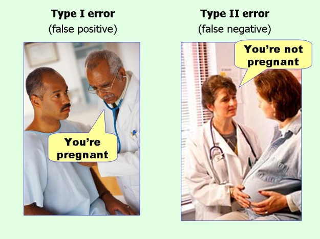

# What p-values can and cannot do

> A p-value is the probability under a specified statistical model that a statistical summary of the data would be equal to or more extreme than its observed values.
- Frequentist inference
- Indicate how incompatible the data are with a specified statistical model
- Does not prove the alternative hypothesis to be true
- Does not prove the null hypothesis to be true

# What p-values can and cannot do

# What p-values can and cannot do

- $0.05$ threshold
- Size and importance of a result
- Other plausible explanations

# How to find a significant p-value

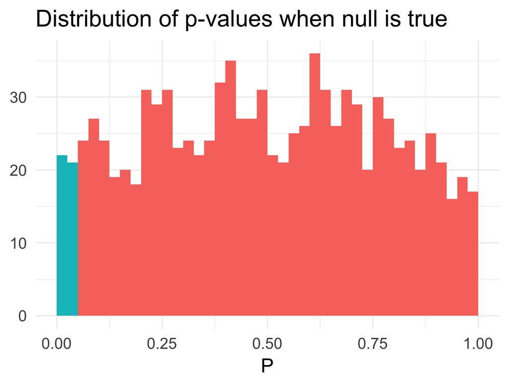

# How to find a significant p-value

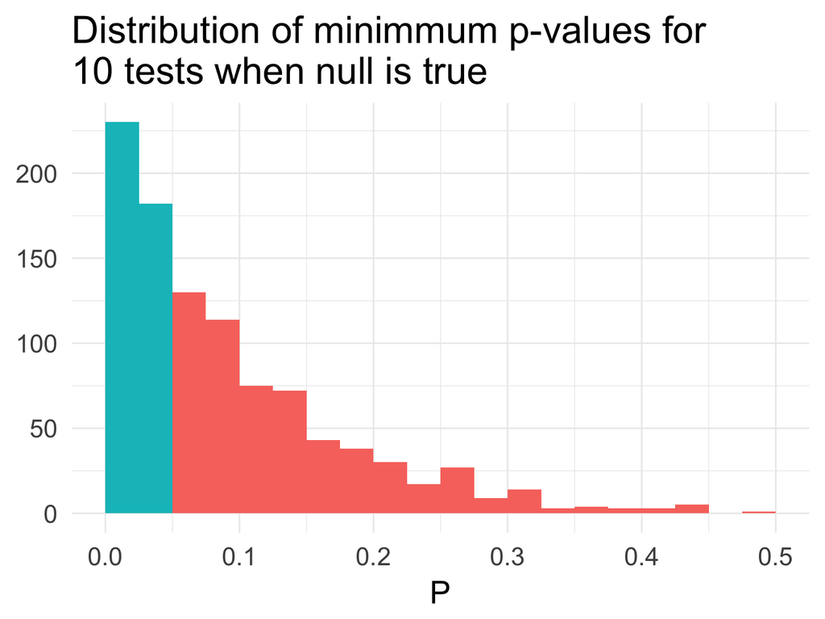

# How to find a significant p-value

- False discovery
- Selection bias
- Researcher degrees of freedom

# Confidence intervals don’t save us

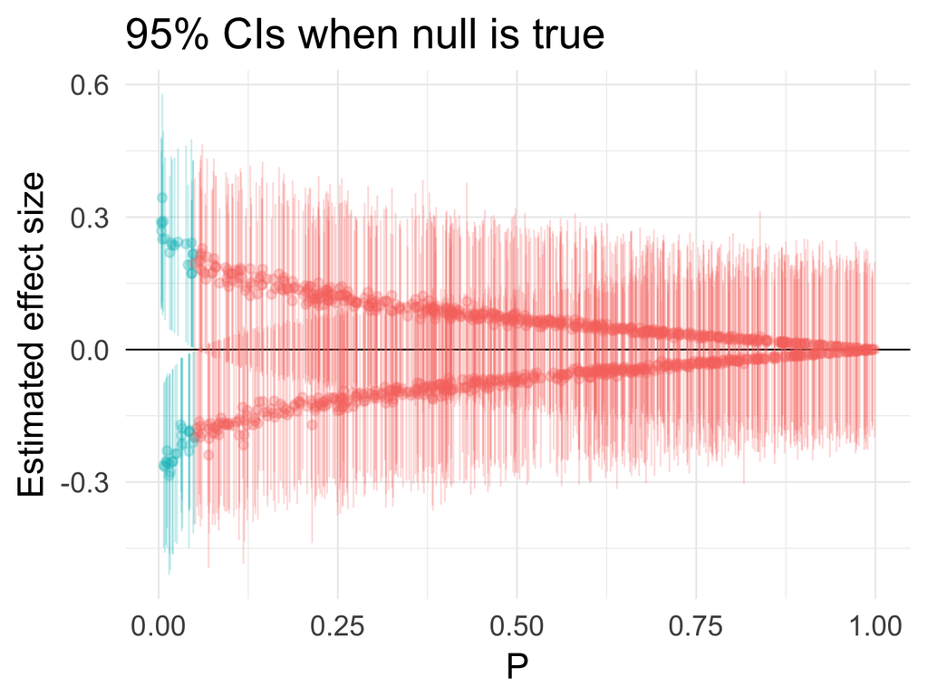

# Confidence intervals don’t save us

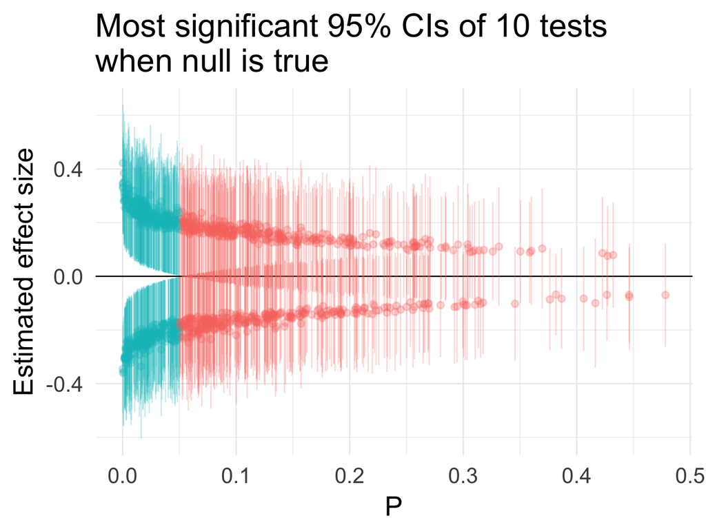

# Best subset selection

1. Let $M_0$ denote the null model which contains no predictors. This model simply predicts the sample mean for each observation.
2. For $k = 1, 2, \dots, p$:
   1. Fit all ${p}\choose{k}$ models that contain exactly $k$ predictors
   2. Pick the best among these ${p}\choose{k}$ models and call it $M_k$. Best is defined by the smallest RSS or RMSE, or largest $R^2$
3. Select a single best model from among $M_0, \dots, M_p$ using cross-validated prediction error or similar metrics

# Forward stepwise regression

# Backward stepwise regression

# Subset selection and p-values

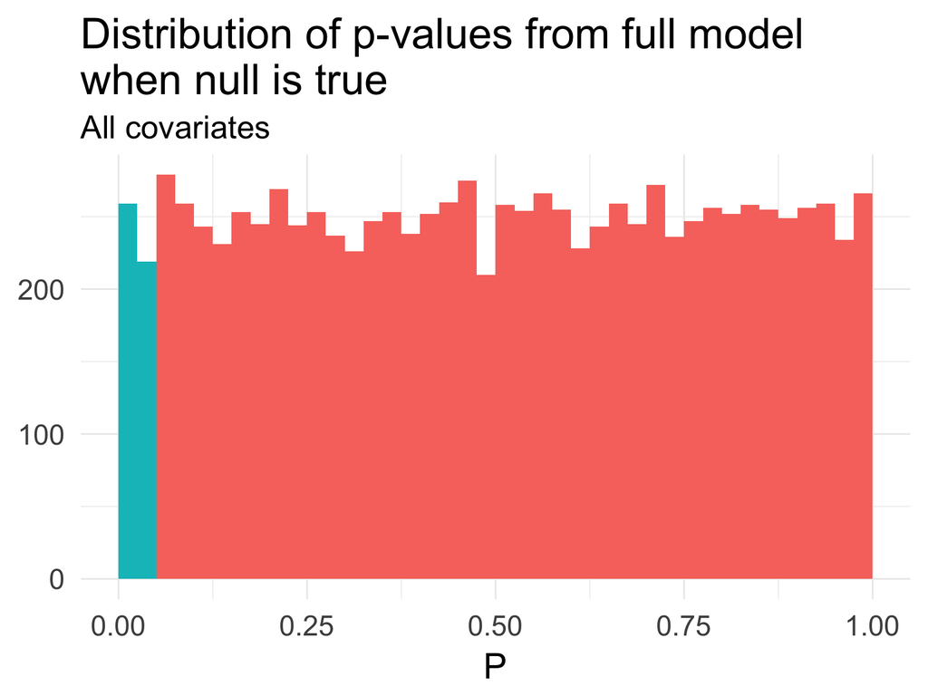

# Subset selection and p-values

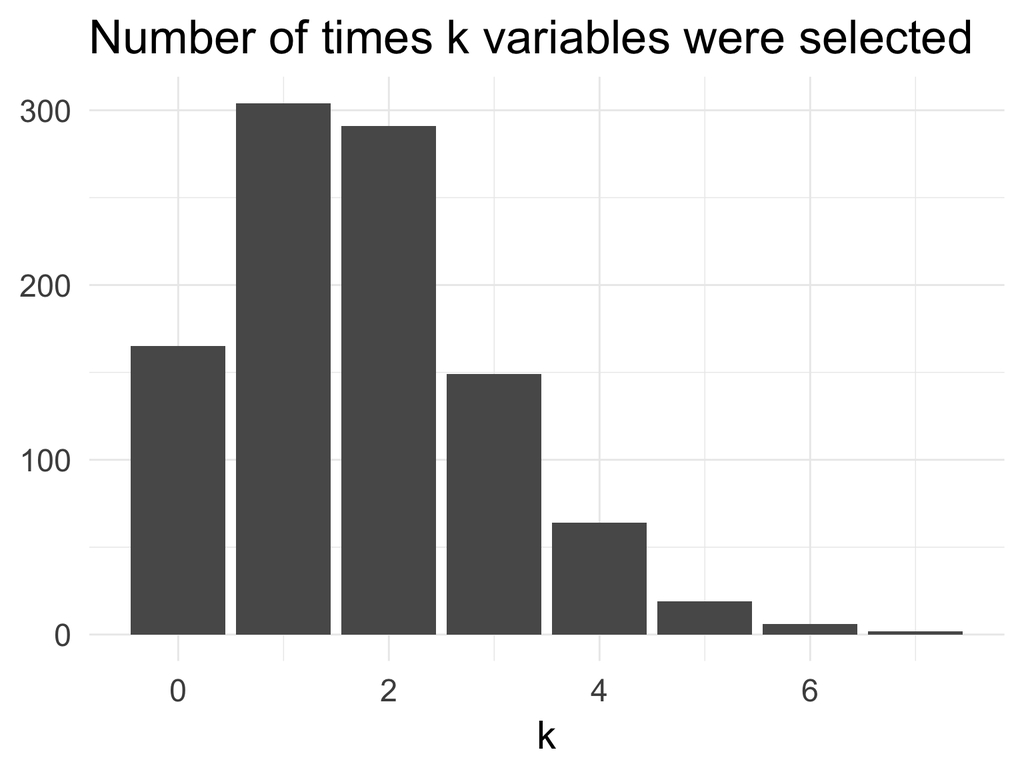

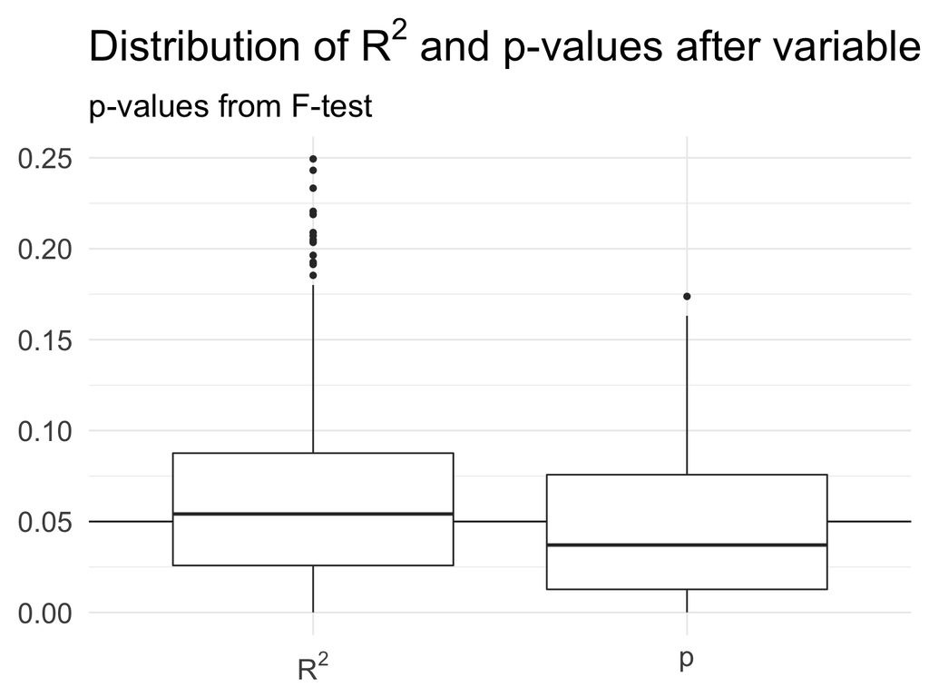

# Finding p-values without trying

[figure not shown]

# Article critique

- [Beall, A. T., & Tracy, J. L. (2013). Women are more likely to wear red or pink at peak fertility. *Psychological Science*, 0956797613476045.](http://journals.sagepub.com.proxy.uchicago.edu/doi/abs/10.1177/0956797613476045)
- [“Too Good to Be True” by Andrew Gelman. *Slate*.](http://www.slate.com/articles/health_and_science/science/2013/07/statistics_and_psychology_multiple_comparisons_give_spurious_results.html)
- [“Response by Jessica Tracy and Alec Beall to my critique of the methods in their paper, ‘Women Are More Likely to Wear Red or Pink at Peak Fertility’” by Andrew Gelman.](http://andrewgelman.com/2013/07/31/response-by-jessica-tracy-and-alec-beall-to-my-criticism-of-their-paper/)

# Preventing false discovery

- Cross-validation
- p-value correction
- Pre-registration

# Corrected p-values

- Family-wise error rate (FWER)
- Bonferroni correction

# Bonferroni correction

[output not shown]

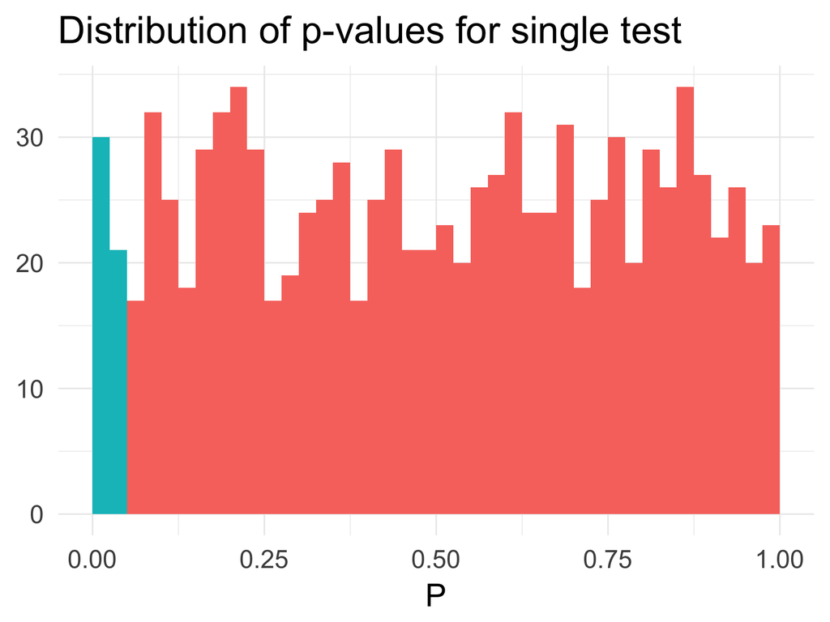

# Bonferroni correction

```
## # A tibble: 1 x 1
##   `mean(sig)`
##         <dbl>
## 1       0.239
```

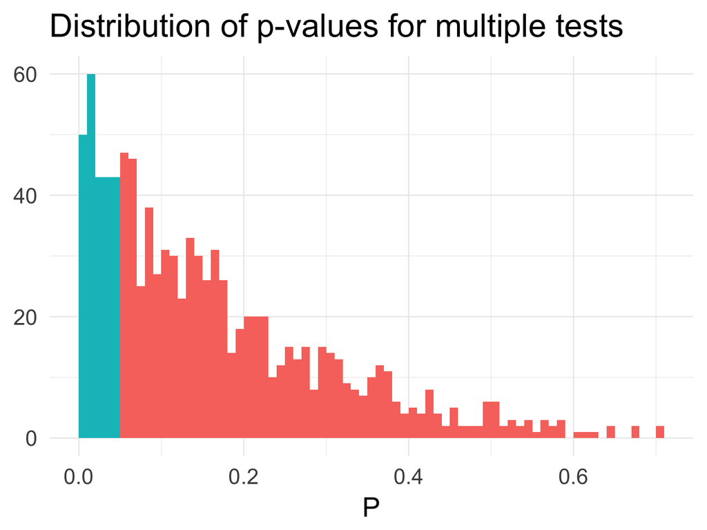

# Bonferroni correction

```
## # A tibble: 1 x 1
##   `mean(sig)`
##         <dbl>
## 1        0.05
```

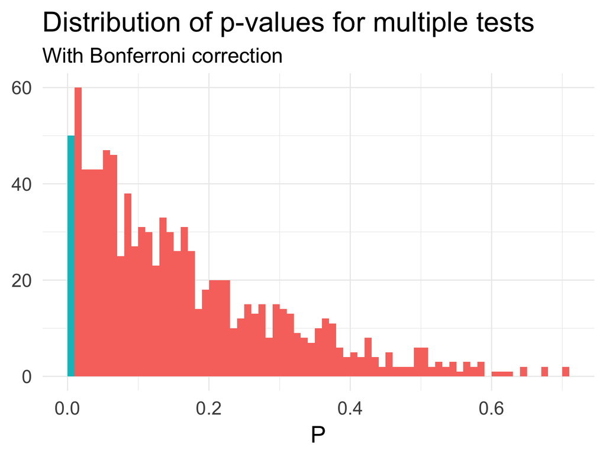

# Pre-registration of research design

- What it is
- Benefits
- Concerns